# HW 8: SQL

Use the code below to establish a connection with `custom_parlgov.db` from class.

```r
library(tidyverse)
library(DBI)

fileloc<-here::here("Data", "custom_parlgov.db")
con <- dbConnect(RSQLite::SQLite(), fileloc)

dbListTables(con)
```

```
[1] "country"               "election"              "party"
[4] "party_election_result"
```

## Question 1

The full ParlGov dataset includes some additional data on the president of each country. The data has the following format:

| id | country_id | start_date | end_date | person_id | president_name | party_id |
| --- | --- | --- | --- | --- | --- | --- |
| 1 | 40 | 1966-01-01 | 1966-12-31 | 7243 | Hans Schaffner | 26 |
| 2 | 37 | 1974-12-19 | 1976-10-22 | 17075 | Cearbhall Ó Dálaigh | 30 |
| 3 | 74 | 1989-12-31 | 1990-12-22 | 17095 | Wojciech Jaruzelski | 1077 |
| 4 | 59 | 1951-06-21 | 1957-01-04 | 12553 | Theodor Körner | 973 |
| 5 | 40 | 1961-01-01 | 1961-12-31 | 3131 | Friedrich Traugott Wahlen | 750 |

Which of these options would be the best way to include this table into our existing database? Give a brief justification of your reasoning.

- A. Add this to the database as a separate table.
- B. Add the presidential characteristics to the `party` table.
- C. Add the presidential characteristics to the `election` table.
- D. Add the presidential characteristics to the `party_election_result` table.

## Question 2

Use joins to create a single combined table that includes the following columns:

- `country.country_name`
- `election.election_date`
- `party.party_name`
- `party_election_result.vote_share`
- `party_election_result.seat_share`

## Question 3

Many political scientists have argued that the more centrist political party families (specifically: Liberal, Social democracy, Conservative and Christian democracy parties) have seen a gradual decline in support since the 1970s.

Use a SQL statement to create a table that show the combined vote share going to centrist political parties in each election in each country. Your table should include at least the following variables:

- Country name
- Election date
- Combined vote share for centrist party families in each country/election.

Import this table into R and then make a graph or table to either refute or support this claim (I don’t expect a definitive answer with a single graph, just try to come up with a way to illustrate the evidence.)

Note: SQLite doesn’t have a designated date class, so you may need to use `as.Date()` to convert `election_date` into the proper format in R before you can make your plot.

```sql
SELECT
country.country_name_short,
election.election_date,
election_id, sum(vote_share) as vote_share from party_election_result
join election on party_election_result.election_id = election.id
join country on country.id = election.country_id
WHERE party_id in
(SELECT id from party where family_name IN
('Christian democracy' ,'Conservative', 'Social democracy', 'Liberal'))
AND vote_share is not null
group by election_id
```

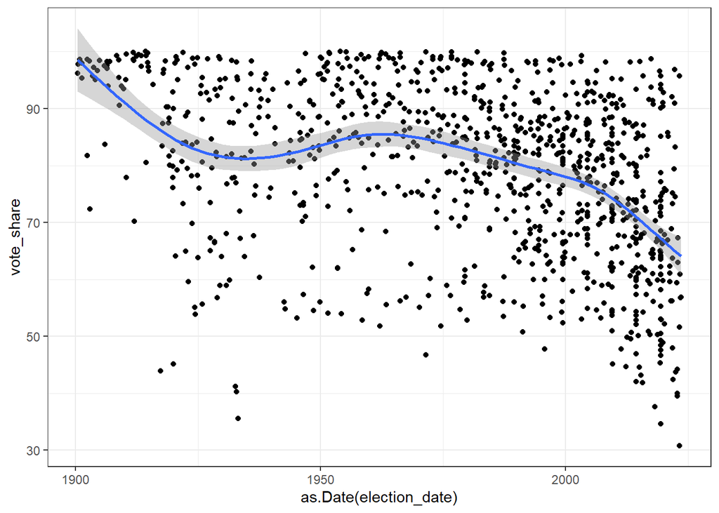

```r
ggplot(mainstream_parties, aes(x=as.Date(election_date), y=vote_share)) +
  geom_point() +
  geom_smooth() +
  theme_bw()
```